# ML Project: Airline Passenger Satisfaction

### Examination of individual variables:

- Looking at variables we hypothesize will be strongly related to customer satisfaction:

#### Age

```r
summary(airline_data$Age)
```

```
##    Min. 1st Qu.  Median    Mean 3rd Qu.    Max.
##    7.00   27.00   40.00   39.43   51.00   85.00
```

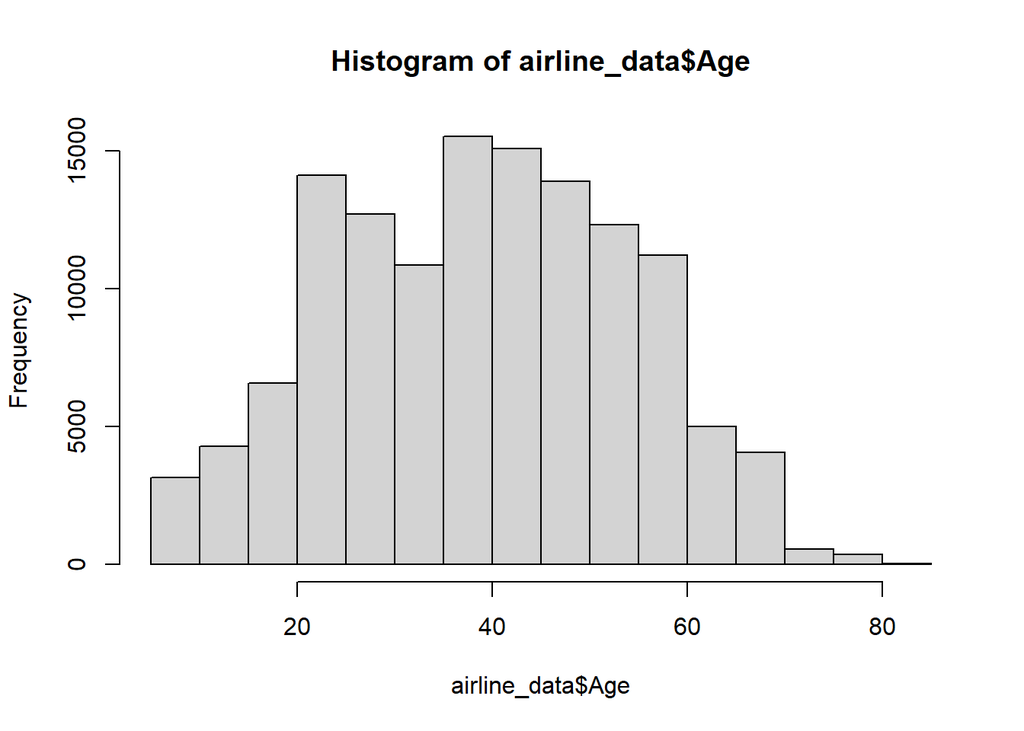

```r
hist(airline_data$Age)
```

The plot reveals that there are no significantly over represented groups within the `Age` variable, with the highest number of responses coming from people within the range of roughly 35-55 years old.

#### Gender

```r
table(airline_data$Gender)
```

```
##
## Female   Male
##  65899  63981
```

#### Customer Type - loyal or disloyal

```r
table(airline_data$Customer.Type)
```

```
##
## disloyal Customer    Loyal Customer
##             23780            106100
```

```r
# many more loyal customers than non loyal
```

#### Type of Travel and Class Traveled

```r
table(airline_data$Type.of.Travel) # way more travel for business than personal reasons
```

```
##
## Business travel Personal Travel
##           89693           40187
```

```r
table(airline_data$Class)
```

```
##
## Business      Eco Eco Plus
##    62160    58309     9411
```

#### Cleanliness

```r
table(airline_data$Cleanliness)
```

```
##
##     0     1     2     3     4     5
##    14 16729 20113 30639 33969 28416
```

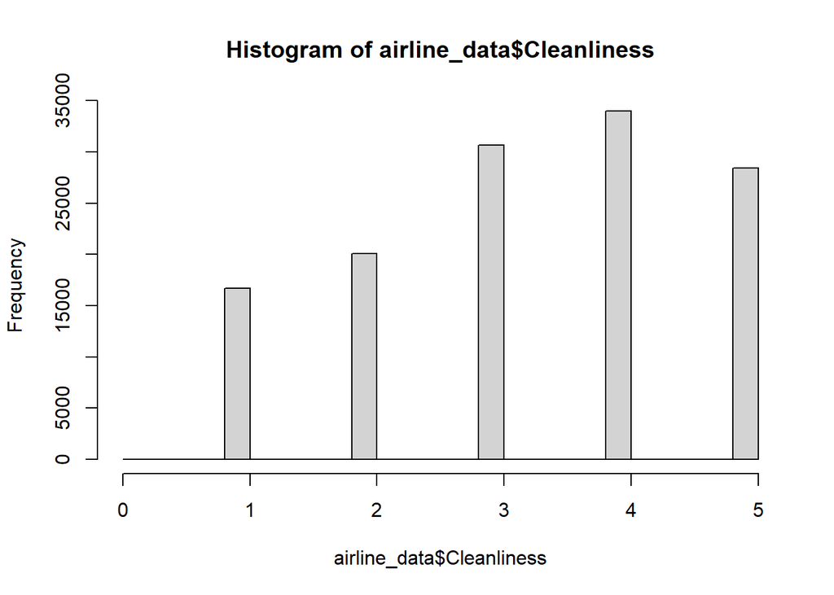

```r
hist(airline_data$Cleanliness)
```

While not used in the most conventional way, this visual allows us to visually examine the distribution of responant ratings within the `Cleanliness` variable. It enables us to easily identify that most people rated airplane cleanliness in the 3-5 range.

#### Flight Distance

```r
summary(airline_data$Flight.Distance)
```

```
##    Min. 1st Qu.  Median    Mean 3rd Qu.    Max.
##      31     414     844    1190    1744    4983
```

#### Inflight Entertainment and Wifi Service Rating Distributions

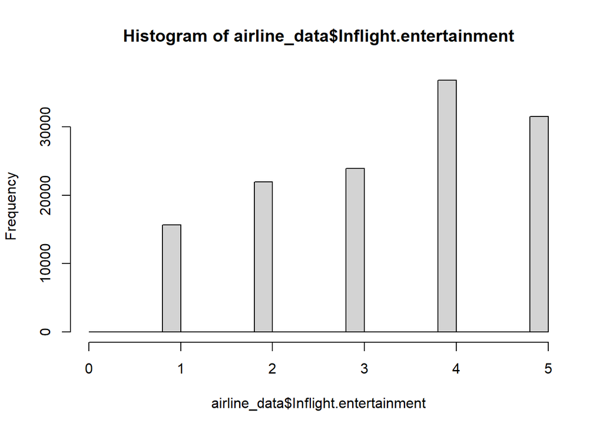

```r
hist(airline_data$Inflight.entertainment)
```

The `Inflight.entertainment` histogram reveals that in general most people are fairly satisfied with their in flight entertainment options, with 4 as the mode of the ratings.

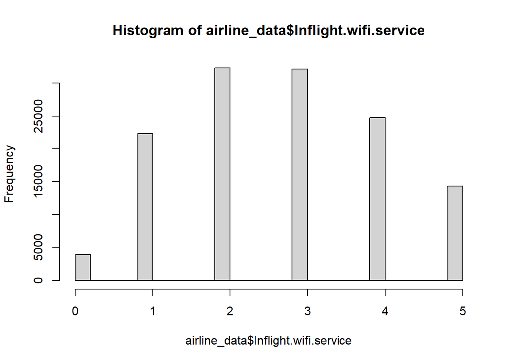

```r
hist(airline_data$Inflight.wifi.service)
```

The `Inflight.wifi.service` visual reveals that in flight WiFi may be an area for improvement for airlines as most respondents rated the service around 2 or 3 out of a possible 5.

#### CheckIn Service

```r
# summary(airline_data$Checkin.service)
table(airline_data$Checkin.service)
```

```
##
##     0     1     2     3     4     5
##     1 16108 16102 35453 36333 25883
```

#### Arrival Delay

```r
summary(airline_data$Arrival.Delay.in.Minutes)
```

```
##    Min. 1st Qu.  Median    Mean 3rd Qu.    Max.
##    0.00    0.00    0.00   15.05   13.00 1584.00
```

The median arrival delay being 0 indicates that the vast majority of flights had no delay at all.

#### Departure Delay

```r
summary(airline_data$Departure.Delay.in.Minutes)
```

```
##    Min. 1st Qu.  Median    Mean 3rd Qu.    Max.
##    0.00    0.00    0.00   14.71   12.00 1592.00
```

The median departure delay being 0 indicates that the vast majority of flights had no delay at all.

## Data Visualizations

#### Relationship between Cleanliness and Class flown:

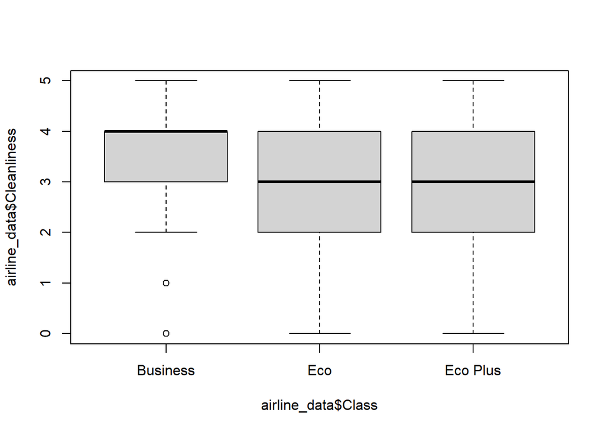

```r
boxplot(airline_data$Cleanliness ~ airline_data$Class)
```

This boxplot reveals that the distribution of customers’ `Cleanliness` rating somewhat differs when examined by `Class` flown. It is clear that the median cleanliness rating for business class flyers is higher than ratings of those who flew in economy plus or economy. Interestingly, there is not a similar difference reflected in the cleanliness ratings between the economy and economy plus categories. This indicates that the divide to focus on is that between the business class and the rest of the classes.

#### Flight Distance by Inflight Service Ratings

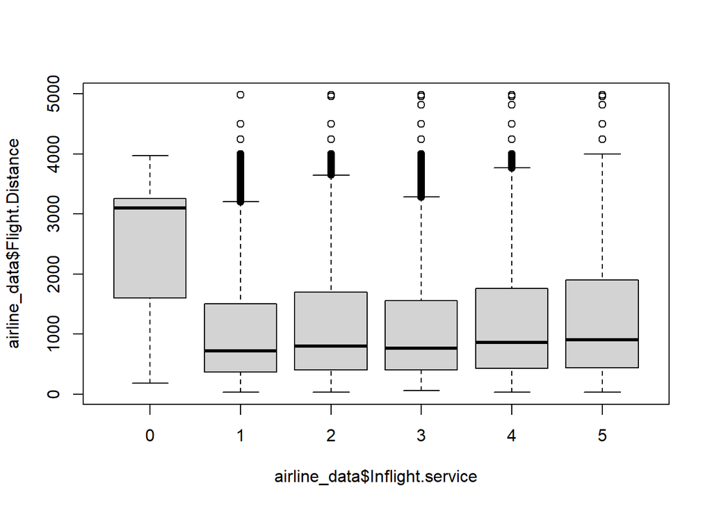

```r
boxplot(airline_data$Flight.Distance ~ airline_data$Inflight.service)
```

We also wanted to take a look at how `Inflight.service` ratings are distributed by `Flight.Distance`. Notably, all of the ratings of 0 for in flight service correlated with longer median flight distances. This is really surprising as one would reasonably assume that longer flights would be accompanied by better in flight service, so this observation is definitely something we will further examine later in our analysis. With the exception of the 0 category, however, the remaining in flight service ratings are all relatively evenly distributed between 1 and 5, with the flight distances for each rating also being generally very similar.

#### Distribution of Departure Delays (in minutes)

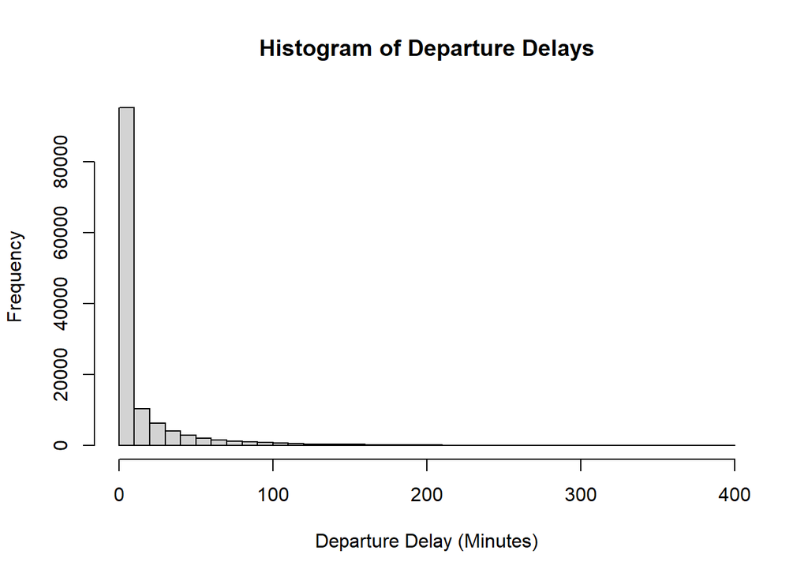

```r
# hist(airline_data$Departure.Delay.in.Minutes)
subset_most_vals <- airline_data$Departure.Delay.in.Minutes[airline_data$Departure.Delay.in.Minutes < 400]
breaks <- seq(0, 400, by = 10)  # Create bins every 10 minutes
hist(subset_most_vals,
     breaks = breaks,  # Use the custom breaks
     main = "Histogram of Departure Delays",
     xlab = "Departure Delay (Minutes)",
     ylab = "Frequency")
```

## Logsitic Regression

Preliminary Steps - Analyzing the response Variable

```r
summary(train_data$satisfaction)
```

```
##    Length     Class      Mode
##    103904 character character
```

[figure not shown]

```r
g_1 <- ggplot(train_data, aes(x = satisfaction, y = X)) + # Set X-axis as insurance charges
  geom_col(fill = "blue") + # Use geom_density to get density plot
  theme_bw() + # Set theme for plot
  theme(panel.grid.major = element_blank(), # Turn of the background grid
        panel.grid.minor = element_blank(),
        panel.border = element_blank(),
        panel.background = element_blank()) +
  labs(x = "Satisfactions", y = "Number of Respondents", # Set plot labels
       title = "Overview of Satisfaction")

g_1 # Generate plot
```

Since the response variable, satisfaction, is categorical we are using logistic regression.

```r
# Converting the chr data type for satisfaction to numeric, having 'satisfied' by 1 and 'neutral or dissatisfied' by 0
use_data <- train_data[,-c(1:2)] # Dropped the first two columns because they were identification columns we don't need in our model.
use_data$satisfaction <- as.numeric(use_data$satisfaction == "satisfied")


fit_1 <- glm(satisfaction ~ ., # Set formula
             family=binomial(link='logit'), # Set logistic regression
             data= use_data) # Set dataset
t1 <- summary(fit_1) # Summarize model
t1
```

```
##
## Call:
## glm(formula = satisfaction ~ ., family = binomial(link = "logit"),
##     data = use_data)
##
## Coefficients:
##                                     Estimate Std. Error  z value Pr(>|z|)
## (Intercept)                       -7.867e+00  7.864e-02 -100.033  < 2e-16 ***
## GenderMale                         4.064e-02  1.946e-02    2.088  0.03680 *
## Customer.TypeLoyal Customer        2.036e+00  2.990e-02   68.090  < 2e-16 ***
## Age                               -8.289e-03  7.097e-04  -11.680  < 2e-16 ***
## Type.of.TravelPersonal Travel     -2.720e+00  3.141e-02  -86.614  < 2e-16 ***
## ClassEco                          -7.366e-01  2.563e-02  -28.740  < 2e-16 ***
## ClassEco Plus                     -8.522e-01  4.146e-02  -20.554  < 2e-16 ***
## Flight.Distance                   -1.715e-05  1.130e-05   -1.517  0.12922
## Inflight.wifi.service              3.948e-01  1.146e-02   34.461  < 2e-16 ***
## Departure.Arrival.time.convenient -1.248e-01  8.207e-03  -15.209  < 2e-16 ***
## Ease.of.Online.booking            -1.430e-01  1.133e-02  -12.622  < 2e-16 ***
## Gate.location                      2.930e-02  9.160e-03    3.199  0.00138 **
## Food.and.drink                    -2.760e-02  1.067e-02   -2.588  0.00966 **
## Online.boarding                    6.124e-01  1.023e-02   59.855  < 2e-16 ***
## Seat.comfort                       6.686e-02  1.117e-02    5.988 2.13e-09 ***
## Inflight.entertainment             6.387e-02  1.424e-02    4.484 7.33e-06 ***
## On.board.service                   3.017e-01  1.018e-02   29.647  < 2e-16 ***
## Leg.room.service                   2.530e-01  8.524e-03   29.678  < 2e-16 ***
## Baggage.handling                   1.341e-01  1.142e-02   11.744  < 2e-16 ***
## Checkin.service                    3.237e-01  8.554e-03   37.846  < 2e-16 ***
## Inflight.service                   1.201e-01  1.203e-02    9.989  < 2e-16 ***
## Cleanliness                        2.231e-01  1.208e-02   18.464  < 2e-16 ***
## Departure.Delay.in.Minutes         4.132e-03  9.188e-04    4.497 6.88e-06 ***
## Arrival.Delay.in.Minutes          -8.816e-03  9.096e-04   -9.692  < 2e-16 ***
## ---
## Signif. codes:  0 '***' 0.001 '**' 0.01 '*' 0.05 '.' 0.1 ' ' 1
##
## (Dispersion parameter for binomial family taken to be 1)
##
##     Null deviance: 142189  on 103903  degrees of freedom
## Residual deviance:  69384  on 103880  degrees of freedom
## AIC: 69432
##
## Number of Fisher Scoring iterations: 6
```

```r
# We want the lowest AIC value since the model with a lower value is considered the best fit, as it balances model complexity with explanatory power.
#We can test removing insignificant variables and seeing if it helps lower the AIC value
```

Lets look at the predictors that aren’t significant to remove them on by one and see how that impacts the AIC value:

```r
# All the insignificant variables that have a significance level above a 0.01
t1$coefficients[which(t1$coefficients[,4] >= 0.01),]
```

```
##                      Estimate   Std. Error   z value  Pr(>|z|)
## GenderMale       0.0406405147 1.946425e-02  2.087957 0.0368017
## Flight.Distance -0.0000171455 1.130083e-05 -1.517189 0.1292189
```

```r
# Removing Flight Distance predictor
fit_2 <- glm(satisfaction ~ Gender+Customer.Type+Age+Type.of.Travel+Class+Inflight.wifi.service+Departure.Arrival.time.convenient+Ease.of.Online.booking+Gate.location+Food.and.drink+Online.boarding+Seat.comfort+Inflight.entertainment+On.board.service+Leg.room.service+Baggage.handling+Checkin.service+Inflight.service+Cleanliness+Departure.Delay.in.Minutes+Arrival.Delay.in.Minutes, # Set formula
             family=binomial(link='logit'), # Set logistic regression
             data= use_data) # Set dataset
t2 <- summary(fit_2) # Summarize model
t2
```

```
##
## Call:
## glm(formula = satisfaction ~ Gender + Customer.Type + Age + Type.of.Travel +
##     Class + Inflight.wifi.service + Departure.Arrival.time.convenient +
##     Ease.of.Online.booking + Gate.location + Food.and.drink +
##     Online.boarding + Seat.comfort + Inflight.entertainment +
##     On.board.service + Leg.room.service + Baggage.handling +
##     Checkin.service + Inflight.service + Cleanliness + Departure.Delay.in.Minutes +
##     Arrival.Delay.in.Minutes, family = binomial(link = "logit"),
##     data = use_data)
##
## Coefficients:
##                                     Estimate Std. Error  z value Pr(>|z|)
## (Intercept)                       -7.8869198  0.0775525 -101.698  < 2e-16 ***
## GenderMale                         0.0407309  0.0194639    2.093  0.03638 *
## Customer.TypeLoyal Customer        2.0240446  0.0288389   70.185  < 2e-16 ***
## Age                               -0.0082184  0.0007081  -11.606  < 2e-16 ***
## Type.of.TravelPersonal Travel     -2.7148978  0.0311918  -87.039  < 2e-16 ***
## ClassEco                          -0.7244092  0.0243433  -29.758  < 2e-16 ***
## ClassEco Plus                     -0.8375671  0.0403053  -20.781  < 2e-16 ***
## Inflight.wifi.service              0.3957421  0.0114419   34.587  < 2e-16 ***
## Departure.Arrival.time.convenient -0.1250235  0.0082051  -15.237  < 2e-16 ***
## Ease.of.Online.booking            -0.1433180  0.0113275  -12.652  < 2e-16 ***
## Gate.location                      0.0294373  0.0091583    3.214  0.00131 **
## Food.and.drink                    -0.0273874  0.0106666   -2.568  0.01024 *
## Online.boarding                    0.6119540  0.0102273   59.835  < 2e-16 ***
## Seat.comfort                       0.0665578  0.0111636    5.962 2.49e-09 ***
## Inflight.entertainment             0.0638142  0.0142439    4.480 7.46e-06 ***
## On.board.service                   0.3014637  0.0101721   29.636  < 2e-16 ***
## Leg.room.service                   0.2525611  0.0085186   29.648  < 2e-16 ***
## Baggage.handling                   0.1343824  0.0114177   11.770  < 2e-16 ***
## Checkin.service                    0.3236224  0.0085527   37.838  < 2e-16 ***
## Inflight.service                   0.1204801  0.0120215   10.022  < 2e-16 ***
## Cleanliness                        0.2230692  0.0120856   18.457  < 2e-16 ***
## Departure.Delay.in.Minutes         0.0041179  0.0009182    4.485 7.30e-06 ***
## Arrival.Delay.in.Minutes          -0.0088035  0.0009091   -9.684  < 2e-16 ***
## ---
## Signif. codes:  0 '***' 0.001 '**' 0.01 '*' 0.05 '.' 0.1 ' ' 1
##
## (Dispersion parameter for binomial family taken to be 1)
##
##     Null deviance: 142189  on 103903  degrees of freedom
## Residual deviance:  69386  on 103881  degrees of freedom
## AIC: 69432
##
## Number of Fisher Scoring iterations: 6
```

```r
t2$coefficients[which(t2$coefficients[,4] >= 0.01),]
```

```
##                   Estimate Std. Error   z value   Pr(>|z|)
## GenderMale      0.04073092 0.01946392  2.092637 0.03638155
## Food.and.drink -0.02738738 0.01066658 -2.567588 0.01024087
```

```r
# No difference in AIC, lets move forward to removing Gender
```

```r
# Removing Gender predictor
fit_3 <- glm(satisfaction ~ Customer.Type+Age+Type.of.Travel+Class+Inflight.wifi.service+Departure.Arrival.time.convenient+Ease.of.Online.booking+Gate.location+Food.and.drink+Online.boarding+Seat.comfort+Inflight.entertainment+On.board.service+Leg.room.service+Baggage.handling+Checkin.service+Inflight.service+Cleanliness+Departure.Delay.in.Minutes+Arrival.Delay.in.Minutes, # Set formula
             family=binomial(link='logit'), # Set logistic regression
             data= use_data) # Set data set
t3 <- summary(fit_3) # Summarize model
t3
```

```
##
## Call:
## glm(formula = satisfaction ~ Customer.Type + Age + Type.of.Travel +
##     Class + Inflight.wifi.service + Departure.Arrival.time.convenient +
##     Ease.of.Online.booking + Gate.location + Food.and.drink +
##     Online.boarding + Seat.comfort + Inflight.entertainment +
##     On.board.service + Leg.room.service + Baggage.handling +
##     Checkin.service + Inflight.service + Cleanliness + Departure.Delay.in.Minutes +
##     Arrival.Delay.in.Minutes, family = binomial(link = "logit"),
##     data = use_data)
##
## Coefficients:
##                                     Estimate Std. Error  z value Pr(>|z|)
## (Intercept)                       -7.8686770  0.0770355 -102.144  < 2e-16 ***
## Customer.TypeLoyal Customer        2.0262206  0.0288220   70.301  < 2e-16 ***
## Age                               -0.0082262  0.0007082  -11.615  < 2e-16 ***
## Type.of.TravelPersonal Travel     -2.7158026  0.0311919  -87.067  < 2e-16 ***
## ClassEco                          -0.7249898  0.0243426  -29.783  < 2e-16 ***
## ClassEco Plus                     -0.8391106  0.0402928  -20.825  < 2e-16 ***
## Inflight.wifi.service              0.3962178  0.0114378   34.641  < 2e-16 ***
## Departure.Arrival.time.convenient -0.1252034  0.0082046  -15.260  < 2e-16 ***
## Ease.of.Online.booking            -0.1429661  0.0113239  -12.625  < 2e-16 ***
## Gate.location                      0.0292743  0.0091573    3.197  0.00139 **
## Food.and.drink                    -0.0266279  0.0106543   -2.499  0.01245 *
## Online.boarding                    0.6112282  0.0102200   59.807  < 2e-16 ***
## Seat.comfort                       0.0660328  0.0111614    5.916 3.29e-09 ***
## Inflight.entertainment             0.0627396  0.0142301    4.409 1.04e-05 ***
## On.board.service                   0.3009819  0.0101711   29.592  < 2e-16 ***
## Leg.room.service                   0.2527293  0.0085175   29.672  < 2e-16 ***
## Baggage.handling                   0.1348151  0.0114143   11.811  < 2e-16 ***
## Checkin.service                    0.3237134  0.0085523   37.851  < 2e-16 ***
## Inflight.service                   0.1207557  0.0120215   10.045  < 2e-16 ***
## Cleanliness                        0.2239554  0.0120726   18.551  < 2e-16 ***
## Departure.Delay.in.Minutes         0.0041338  0.0009182    4.502 6.73e-06 ***
## Arrival.Delay.in.Minutes          -0.0088180  0.0009091   -9.700  < 2e-16 ***
## ---
## Signif. codes:  0 '***' 0.001 '**' 0.01 '*' 0.05 '.' 0.1 ' ' 1
##
## (Dispersion parameter for binomial family taken to be 1)
##
##     Null deviance: 142189  on 103903  degrees of freedom
## Residual deviance:  69390  on 103882  degrees of freedom
## AIC: 69434
##
## Number of Fisher Scoring iterations: 6
```

```r
# Increased AIC by 2. We should keep Gender. Removing these insignificant predictors isn't helping our AIC, lets instead try adding an interactive term
```

Since we have reached a point where the AIC value isn’t improving, lets try to improve the model by adding interactive terms.

To determine which variables to use for an interaction term in a statistical model, we identify two independent variables where we suspect the effect of one variable significantly changes depending on the level of the other variable.

```r
# included the interactive term of Class and Inflight entertainment
int1 <- glm(satisfaction ~ . + Class * Inflight.entertainment, # Set formula with interaction terms
             family=binomial(link='logit'), # Set logistic regression
             data= use_data) # Set dataset
t5 <- summary(int1)
t5
```

```
##
## Call:
## glm(formula = satisfaction ~ . + Class * Inflight.entertainment,
##     family = binomial(link = "logit"), data = use_data)
##
## Coefficients:
##                                        Estimate Std. Error  z value Pr(>|z|)
## (Intercept)                          -8.294e+00  8.271e-02 -100.281  < 2e-16
## GenderMale                            3.593e-02  1.955e-02    1.838   0.0661
## Customer.TypeLoyal Customer           2.008e+00  2.993e-02   67.064  < 2e-16
## Age                                  -8.226e-03  7.124e-04  -11.547  < 2e-16
## Type.of.TravelPersonal Travel        -2.679e+00  3.107e-02  -86.220  < 2e-16
## ClassEco                              4.933e-01  6.066e-02    8.132 4.24e-16
## ClassEco Plus                        -2.850e-01  1.224e-01   -2.328   0.0199
## Flight.Distance                      -2.193e-05  1.149e-05   -1.909   0.0563
## Inflight.wifi.service                 4.138e-01  1.159e-02   35.695  < 2e-16
## Departure.Arrival.time.convenient    -1.223e-01  8.200e-03  -14.916  < 2e-16
## Ease.of.Online.booking               -1.463e-01  1.137e-02  -12.862  < 2e-16
## Gate.location                         2.766e-02  9.185e-03    3.012   0.0026
## Food.and.drink                       -1.324e-02  1.079e-02   -1.227   0.2199
## Online.boarding                       5.963e-01  1.033e-02   57.723  < 2e-16
## Seat.comfort                          7.328e-02  1.124e-02    6.520 7.01e-11
## Inflight.entertainment                2.423e-01  1.666e-02   14.544  < 2e-16
## On.board.service                      2.888e-01  1.017e-02   28.398  < 2e-16
## Leg.room.service                      2.286e-01  8.606e-03   26.560  < 2e-16
## Baggage.handling                      1.203e-01  1.142e-02   10.534  < 2e-16
## Checkin.service                       3.220e-01  8.578e-03   37.543  < 2e-16
## Inflight.service                      1.053e-01  1.201e-02    8.765  < 2e-16
## Cleanliness                           2.385e-01  1.220e-02   19.557  < 2e-16
## Departure.Delay.in.Minutes            4.038e-03  9.244e-04    4.368 1.25e-05
## Arrival.Delay.in.Minutes             -8.871e-03  9.151e-04   -9.694  < 2e-16
## ClassEco:Inflight.entertainment      -3.819e-01  1.720e-02  -22.207  < 2e-16
## ClassEco Plus:Inflight.entertainment -1.849e-01  3.393e-02   -5.450 5.04e-08
##
## (Intercept)                          ***
## GenderMale                           .
## Customer.TypeLoyal Customer          ***
## Age                                  ***
## Type.of.TravelPersonal Travel        ***
## ClassEco                             ***
```

[output cut: 15 more lines]

```
## Cleanliness                          ***
## Departure.Delay.in.Minutes           ***
## Arrival.Delay.in.Minutes             ***
## ClassEco:Inflight.entertainment      ***
## ClassEco Plus:Inflight.entertainment ***
## ---
## Signif. codes:  0 '***' 0.001 '**' 0.01 '*' 0.05 '.' 0.1 ' ' 1
##
## (Dispersion parameter for binomial family taken to be 1)
##
##     Null deviance: 142189  on 103903  degrees of freedom
## Residual deviance:  68890  on 103878  degrees of freedom
## AIC: 68942
##
## Number of Fisher Scoring iterations: 6
```

```r
# included the interactive term of customer type and chec in service
int2 <- glm(satisfaction ~ . + (Class * Inflight.entertainment) + (Customer.Type * Checkin.service), # Set formula with interaction terms
             family=binomial(link='logit'), # Set logistic regression
             data= use_data) # Set dataset
t6 <- summary(int2)
t6
```

```
##
## Call:
## glm(formula = satisfaction ~ . + (Class * Inflight.entertainment) +
##     (Customer.Type * Checkin.service), family = binomial(link = "logit"),
##     data = use_data)
##
## Coefficients:
##                                               Estimate Std. Error z value
## (Intercept)                                 -7.836e+00  1.006e-01 -77.900
## GenderMale                                   3.738e-02  1.955e-02   1.912
## Customer.TypeLoyal Customer                  1.477e+00  7.363e-02  20.065
## Age                                         -8.240e-03  7.129e-04 -11.558
## Type.of.TravelPersonal Travel               -2.701e+00  3.137e-02 -86.094
## ClassEco                                     4.646e-01  6.075e-02   7.649
## ClassEco Plus                               -3.083e-01  1.224e-01  -2.518
## Flight.Distance                             -2.538e-05  1.153e-05  -2.202
## Inflight.wifi.service                        4.183e-01  1.164e-02  35.940
## Departure.Arrival.time.convenient           -1.234e-01  8.191e-03 -15.070
## Ease.of.Online.booking                      -1.464e-01  1.139e-02 -12.855
## Gate.location                                2.656e-02  9.179e-03   2.894
## Food.and.drink                              -1.396e-02  1.084e-02  -1.288
## Online.boarding                              5.932e-01  1.035e-02  57.300
## Seat.comfort                                 7.121e-02  1.124e-02   6.335
## Inflight.entertainment                       2.386e-01  1.669e-02  14.300
## On.board.service                             2.901e-01  1.014e-02  28.603
## Leg.room.service                             2.267e-01  8.592e-03  26.381
## Baggage.handling                             1.222e-01  1.141e-02  10.708
## Checkin.service                              1.985e-01  1.790e-02  11.089
## Inflight.service                             1.081e-01  1.200e-02   9.008
## Cleanliness                                  2.384e-01  1.224e-02  19.480
## Departure.Delay.in.Minutes                   4.037e-03  9.264e-04   4.358
## Arrival.Delay.in.Minutes                    -8.896e-03  9.172e-04  -9.699
## ClassEco:Inflight.entertainment             -3.783e-01  1.719e-02 -22.012
## ClassEco Plus:Inflight.entertainment        -1.809e-01  3.390e-02  -5.337
## Customer.TypeLoyal Customer:Checkin.service  1.557e-01  2.001e-02   7.784
##                                             Pr(>|z|)
## (Intercept)                                  < 2e-16 ***
## GenderMale                                   0.05591 .
## Customer.TypeLoyal Customer                  < 2e-16 ***
## Age                                          < 2e-16 ***
```

[output cut: 18 more lines]

```
## Departure.Delay.in.Minutes                  1.31e-05 ***
## Arrival.Delay.in.Minutes                     < 2e-16 ***
## ClassEco:Inflight.entertainment              < 2e-16 ***
## ClassEco Plus:Inflight.entertainment        9.46e-08 ***
## Customer.TypeLoyal Customer:Checkin.service 7.05e-15 ***
## ---
## Signif. codes:  0 '***' 0.001 '**' 0.01 '*' 0.05 '.' 0.1 ' ' 1
##
## (Dispersion parameter for binomial family taken to be 1)
##
##     Null deviance: 142189  on 103903  degrees of freedom
## Residual deviance:  68830  on 103877  degrees of freedom
## AIC: 68884
##
## Number of Fisher Scoring iterations: 6
```

```r
# We reduced the AIC value even further! Lets add one more interactive term
```

```r
# included the interactive term of type of travel and departure delay
int3 <- glm(satisfaction ~ . + (Class * Inflight.entertainment) + (Customer.Type * Checkin.service) + (Type.of.Travel*Departure.Delay.in.Minutes), # Set formula with interaction terms
             family=binomial(link='logit'), # Set logistic regression
             data= use_data) # Set data set
t7 <- summary(int3)
t7
```

```
##
## Call:
## glm(formula = satisfaction ~ . + (Class * Inflight.entertainment) +
##     (Customer.Type * Checkin.service) + (Type.of.Travel * Departure.Delay.in.Minutes),
##     family = binomial(link = "logit"), data = use_data)
##
## Coefficients:
##                                                            Estimate Std. Error
## (Intercept)                                              -7.845e+00  1.006e-01
## GenderMale                                                3.670e-02  1.956e-02
## Customer.TypeLoyal Customer                               1.470e+00  7.359e-02
## Age                                                      -8.321e-03  7.141e-04
## Type.of.TravelPersonal Travel                            -2.598e+00  3.266e-02
## ClassEco                                                  4.573e-01  6.081e-02
## ClassEco Plus                                            -3.186e-01  1.225e-01
## Flight.Distance                                          -2.622e-05  1.153e-05
## Inflight.wifi.service                                     4.149e-01  1.165e-02
## Departure.Arrival.time.convenient                        -1.221e-01  8.200e-03
## Ease.of.Online.booking                                   -1.482e-01  1.140e-02
## Gate.location                                             2.761e-02  9.189e-03
## Food.and.drink                                           -1.937e-02  1.089e-02
## Online.boarding                                           5.963e-01  1.037e-02
## Seat.comfort                                              7.278e-02  1.124e-02
## Inflight.entertainment                                    2.403e-01  1.672e-02
## On.board.service                                          2.898e-01  1.016e-02
## Leg.room.service                                          2.278e-01  8.597e-03
## Baggage.handling                                          1.226e-01  1.141e-02
## Checkin.service                                           1.979e-01  1.789e-02
## Inflight.service                                          1.077e-01  1.202e-02
## Cleanliness                                               2.398e-01  1.225e-02
## Departure.Delay.in.Minutes                                5.621e-03  9.673e-04
## Arrival.Delay.in.Minutes                                 -9.423e-03  9.494e-04
## ClassEco:Inflight.entertainment                          -3.760e-01  1.721e-02
## ClassEco Plus:Inflight.entertainment                     -1.772e-01  3.393e-02
## Customer.TypeLoyal Customer:Checkin.service               1.565e-01  2.000e-02
## Type.of.TravelPersonal Travel:Departure.Delay.in.Minutes -1.019e-02  1.055e-03
##                                                          z value Pr(>|z|)
## (Intercept)                                              -77.975  < 2e-16 ***
## GenderMale                                                 1.876  0.06066 .
## Customer.TypeLoyal Customer                               19.980  < 2e-16 ***
```

[output cut: 20 more lines]

```
## Arrival.Delay.in.Minutes                                  -9.925  < 2e-16 ***
## ClassEco:Inflight.entertainment                          -21.853  < 2e-16 ***
## ClassEco Plus:Inflight.entertainment                      -5.222 1.77e-07 ***
## Customer.TypeLoyal Customer:Checkin.service                7.825 5.06e-15 ***
## Type.of.TravelPersonal Travel:Departure.Delay.in.Minutes  -9.661  < 2e-16 ***
## ---
## Signif. codes:  0 '***' 0.001 '**' 0.01 '*' 0.05 '.' 0.1 ' ' 1
##
## (Dispersion parameter for binomial family taken to be 1)
##
##     Null deviance: 142189  on 103903  degrees of freedom
## Residual deviance:  68710  on 103876  degrees of freedom
## AIC: 68766
##
## Number of Fisher Scoring iterations: 6
```

```r
# We reduced the AIC even further showing we had a good selection for the interactive terms, helping improve the model's performance
```

## Backward Selection

Being used with the initial model with all predictors and it will remove the predictors that are statistically insignificant one by one to lower the AIC value.

```r
lm_bwd <- step(fit_1, direction='backward', k=log(nrow(use_data)))
```

```
## Start:  AIC=69661.01
## satisfaction ~ Gender + Customer.Type + Age + Type.of.Travel +
##     Class + Flight.Distance + Inflight.wifi.service + Departure.Arrival.time.convenient +
##     Ease.of.Online.booking + Gate.location + Food.and.drink +
##     Online.boarding + Seat.comfort + Inflight.entertainment +
##     On.board.service + Leg.room.service + Baggage.handling +
##     Checkin.service + Inflight.service + Cleanliness + Departure.Delay.in.Minutes +
##     Arrival.Delay.in.Minutes
##
##                                     Df Deviance   AIC
## - Flight.Distance                    1    69386 69652
## - Gender                             1    69388 69654
## - Food.and.drink                     1    69390 69656
## - Gate.location                      1    69394 69660
## <none>                                    69384 69661
## - Inflight.entertainment             1    69404 69670
## - Departure.Delay.in.Minutes         1    69404 69670
## - Seat.comfort                       1    69420 69685
## - Arrival.Delay.in.Minutes           1    69478 69743
## - Inflight.service                   1    69484 69750
## - Age                                1    69521 69787
## - Baggage.handling                   1    69522 69788
## - Ease.of.Online.booking             1    69544 69810
## - Departure.Arrival.time.convenient  1    69614 69880
## - Cleanliness                        1    69727 69992
## - Leg.room.service                   1    70270 70536
## - On.board.service                   1    70279 70545
## - Class                              2    70324 70578
## - Inflight.wifi.service              1    70611 70877
## - Checkin.service                    1    70864 71129
## - Online.boarding                    1    73194 73460
## - Customer.Type                      1    74481 74746
## - Type.of.Travel                     1    78202 78467
##
## Step:  AIC=69651.77
## satisfaction ~ Gender + Customer.Type + Age + Type.of.Travel +
##     Class + Inflight.wifi.service + Departure.Arrival.time.convenient +
##     Ease.of.Online.booking + Gate.location + Food.and.drink +
##     Online.boarding + Seat.comfort + Inflight.entertainment +
##     On.board.service + Leg.room.service + Baggage.handling +
```

[output cut: 102 more lines]

```
## - Arrival.Delay.in.Minutes           1    69500 69720
## - Inflight.service                   1    69512 69732
## - Age                                1    69539 69758
## - Baggage.handling                   1    69551 69770
## - Ease.of.Online.booking             1    69558 69777
## - Departure.Arrival.time.convenient  1    69632 69852
## - Cleanliness                        1    69751 69971
## - Leg.room.service                   1    70298 70517
## - On.board.service                   1    70318 70538
## - Class                              2    70431 70639
## - Inflight.wifi.service              1    70638 70858
## - Checkin.service                    1    70880 71099
## - Online.boarding                    1    73288 73507
## - Customer.Type                      1    74858 75077
## - Type.of.Travel                     1    78465 78685
```

## GAM - Generalized Additive Model

Estimate a GAM model with all predictors to capture potential nonlinear relationship. We can use plot() function to visualize the estimated coefficients and splines for each predictor. Note that we can still interpret the estimated model gam1 due to the additivity of GAM.

```r
library(gam)
# put all numerical predictors with a spline of degree of freedom 4

gam1 <-gam(satisfaction~Gender+Customer.Type+s(Age)+Type.of.Travel+Class+s(Inflight.wifi.service)+s(Departure.Arrival.time.convenient)+s(Ease.of.Online.booking)+s(Gate.location)+s(Food.and.drink)+s(Online.boarding)+s(Seat.comfort)+s(Inflight.entertainment)+s(On.board.service)+s(Leg.room.service)+s(Baggage.handling)+s(Checkin.service)+s(Inflight.service)+s(Cleanliness)+s(Departure.Delay.in.Minutes)+s(Arrival.Delay.in.Minutes)+s(Flight.Distance), family='binomial', data=use_data)

summary(gam1)
```

```
##
## Call: gam(formula = satisfaction ~ Gender + Customer.Type + s(Age) +
##     Type.of.Travel + Class + s(Inflight.wifi.service) + s(Departure.Arrival.time.convenient) +
##     s(Ease.of.Online.booking) + s(Gate.location) + s(Food.and.drink) +
##     s(Online.boarding) + s(Seat.comfort) + s(Inflight.entertainment) +
##     s(On.board.service) + s(Leg.room.service) + s(Baggage.handling) +
##     s(Checkin.service) + s(Inflight.service) + s(Cleanliness) +
##     s(Departure.Delay.in.Minutes) + s(Arrival.Delay.in.Minutes) +
##     s(Flight.Distance), family = "binomial", data = use_data)
## Deviance Residuals:
##      Min       1Q   Median       3Q      Max
## -4.26918 -0.23986 -0.05647  0.16659  4.09058
##
## (Dispersion Parameter for binomial family taken to be 1)
##
##     Null Deviance: 142188.8 on 103903 degrees of freedom
## Residual Deviance: 37603.17 on 103826 degrees of freedom
## AIC: 37759.17
##
## Number of Local Scoring Iterations: NA
##
## Anova for Parametric Effects
##                                          Df Sum Sq Mean Sq   F value    Pr(>F)
## Gender                                    1     16    16.1   11.4260 0.0007245
## Customer.Type                             1   1546  1546.3 1097.5350 < 2.2e-16
## s(Age)                                    1    123   123.2   87.4320 < 2.2e-16
## Type.of.Travel                            1  10473 10473.2 7433.6141 < 2.2e-16
## Class                                     2   1035   517.4  367.2439 < 2.2e-16
## s(Inflight.wifi.service)                  1   4369  4368.9 3100.9735 < 2.2e-16
## s(Departure.Arrival.time.convenient)      1    575   575.3  408.3120 < 2.2e-16
## s(Ease.of.Online.booking)                 1     74    74.2   52.6801 3.953e-13
## s(Gate.location)                          1    494   494.1  350.6664 < 2.2e-16
## s(Food.and.drink)                         1    589   589.0  418.0647 < 2.2e-16
## s(Online.boarding)                        1   1963  1963.2 1393.4320 < 2.2e-16
## s(Seat.comfort)                           1    146   146.5  103.9517 < 2.2e-16
## s(Inflight.entertainment)                 1   2045  2044.8 1451.3435 < 2.2e-16
## s(On.board.service)                       1   1391  1390.7  987.1023 < 2.2e-16
## s(Leg.room.service)                       1    798   797.5  566.0682 < 2.2e-16
## s(Baggage.handling)                       1    342   342.3  242.9798 < 2.2e-16
## s(Checkin.service)                        1    814   813.8  577.5936 < 2.2e-16
```

[output cut: 45 more lines]

```
## s(Food.and.drink)                          3       41.5 5.119e-09 ***
## s(Online.boarding)                         3     1587.5 < 2.2e-16 ***
## s(Seat.comfort)                            3     1515.0 < 2.2e-16 ***
## s(Inflight.entertainment)                  3     1113.2 < 2.2e-16 ***
## s(On.board.service)                        3       54.7 8.080e-12 ***
## s(Leg.room.service)                        3      129.5 < 2.2e-16 ***
## s(Baggage.handling)                        3      678.8 < 2.2e-16 ***
## s(Checkin.service)                         3      128.0 < 2.2e-16 ***
## s(Inflight.service)                        3      729.3 < 2.2e-16 ***
## s(Cleanliness)                             3      100.7 < 2.2e-16 ***
## s(Departure.Delay.in.Minutes)              3       31.3 7.511e-07 ***
## s(Arrival.Delay.in.Minutes)                3      287.0 < 2.2e-16 ***
## s(Flight.Distance)                         3       12.8  0.005167 **
## ---
## Signif. codes:  0 '***' 0.001 '**' 0.01 '*' 0.05 '.' 0.1 ' ' 1
```

```r
#plot(gam1, col='blue')
```

#### Model Evaluation

We are going to adjust the satisfaction column in the test data so that it is also numeric like the training data we have been using

```r
test_use_data <- test_data[,-c(1:2)] # Dropped the first two columns because they were identification columns we don't need in our model.
test_use_data$satisfaction <- as.numeric(test_use_data$satisfaction == "satisfied")
```

Doing a model evaluation (out of sample) for the models we have done so far

```r
library(caret)
fit_1_pred <- predict(fit_1, newdata=test_use_data, type='response')
int3_pred <- predict(int3, newdata=test_use_data, type='response')
lm_bwd_pred <- predict(lm_bwd, newdata=test_use_data, type='response')
gam1_pred <- predict(gam1, newdata=test_use_data, type='response')
```

Adjusting the predictors as factors for each model type to then generate their confusion matrix.

For the first logistic regression model:

```r
# Ensure predictions are factors with appropriate levels
pred_factor <- factor(ifelse(fit_1_pred > 0.5, '1', '0'), levels = c('0', '1'))
actual_factor <- factor(test_use_data$satisfaction, levels = c('0', '1'))
# Print levels for debugging
print(levels(pred_factor))
```

```
## [1] "0" "1"
```

```r
print(levels(actual_factor))
```

```
## [1] "0" "1"
```

```r
# Calculate the confusion matrix
fit_1_acc <- confusionMatrix(pred_factor, actual_factor, positive = '1')
print(fit_1_acc)
```

```
## Confusion Matrix and Statistics
##
##           Reference
## Prediction     0     1
##          0 13139  1904
##          1  1434  9499
##
##                Accuracy : 0.8715
##                  95% CI : (0.8674, 0.8755)
##     No Information Rate : 0.561
##     P-Value [Acc > NIR] : < 2.2e-16
##
##                   Kappa : 0.7379
##
##  Mcnemar's Test P-Value : 4.753e-16
##
##             Sensitivity : 0.8330
##             Specificity : 0.9016
##          Pos Pred Value : 0.8688
##          Neg Pred Value : 0.8734
##              Prevalence : 0.4390
##          Detection Rate : 0.3657
##    Detection Prevalence : 0.4209
##       Balanced Accuracy : 0.8673
##
##        'Positive' Class : 1
##
```

For the logistic regression model with all interaction terms:

```r
# Ensure predictions are factors with appropriate levels
pred_factor5 <- factor(ifelse(int3_pred > 0.5, '1', '0'), levels = c('0', '1'))
actual_factor5 <- factor(test_use_data$satisfaction, levels = c('0', '1'))
# Print levels for debugging
print(levels(pred_factor5))
```

```
## [1] "0" "1"
```

```r
print(levels(actual_factor5))
```

```
## [1] "0" "1"
```

```r
# Calculate the confusion matrix
int3_acc <- confusionMatrix(pred_factor5, actual_factor5, positive = '1')
print(int3_acc)
```

```
## Confusion Matrix and Statistics
##
##           Reference
## Prediction     0     1
##          0 13166  1960
##          1  1407  9443
##
##                Accuracy : 0.8704
##                  95% CI : (0.8662, 0.8744)
##     No Information Rate : 0.561
##     P-Value [Acc > NIR] : < 2.2e-16
##
##                   Kappa : 0.7354
##
##  Mcnemar's Test P-Value : < 2.2e-16
##
##             Sensitivity : 0.8281
##             Specificity : 0.9035
##          Pos Pred Value : 0.8703
##          Neg Pred Value : 0.8704
##              Prevalence : 0.4390
##          Detection Rate : 0.3635
##    Detection Prevalence : 0.4177
##       Balanced Accuracy : 0.8658
##
##        'Positive' Class : 1
##
```

For the backward selection model

```r
# Ensure predictions are factors with appropriate levels
pred_factor2 <- factor(ifelse(lm_bwd_pred > 0.5, '1', '0'), levels = c('0', '1'))
actual_factor2 <- factor(test_use_data$satisfaction, levels = c('0', '1'))
# Print levels for debugging
print(levels(pred_factor2))
```

```
## [1] "0" "1"
```

```r
print(levels(actual_factor2))
```

```
## [1] "0" "1"
```

```r
# Calculate the confusion matrix
lm_bwd_acc <- confusionMatrix(pred_factor2, actual_factor2, positive = '1')
print(lm_bwd_acc)
```

```
## Confusion Matrix and Statistics
##
##           Reference
## Prediction     0     1
##          0 13143  1897
##          1  1430  9506
##
##                Accuracy : 0.8719
##                  95% CI : (0.8678, 0.876)
##     No Information Rate : 0.561
##     P-Value [Acc > NIR] : < 2.2e-16
##
##                   Kappa : 0.7388
##
##  Mcnemar's Test P-Value : 6.528e-16
##
##             Sensitivity : 0.8336
##             Specificity : 0.9019
##          Pos Pred Value : 0.8692
##          Neg Pred Value : 0.8739
##              Prevalence : 0.4390
##          Detection Rate : 0.3660
##    Detection Prevalence : 0.4210
##       Balanced Accuracy : 0.8678
##
##        'Positive' Class : 1
##
```

For the GAM model:

```r
# Ensure predictions are factors with appropriate levels
pred_factor3 <- factor(ifelse(gam1_pred > 0.5, '1', '0'), levels = c('0', '1'))
actual_factor3 <- factor(test_use_data$satisfaction, levels = c('0', '1'))
# Print levels for debugging
print(levels(pred_factor3))
```

```
## [1] "0" "1"
```

```r
print(levels(actual_factor3))
```

```
## [1] "0" "1"
```

```r
# Calculate the confusion matrix
gam1_acc <- confusionMatrix(pred_factor3, actual_factor3, positive = '1')
print(gam1_acc)
```

```
## Confusion Matrix and Statistics
##
##           Reference
## Prediction     0     1
##          0 13788   974
##          1   785 10429
##
##                Accuracy : 0.9323
##                  95% CI : (0.9292, 0.9353)
##     No Information Rate : 0.561
##     P-Value [Acc > NIR] : < 2.2e-16
##
##                   Kappa : 0.8623
##
##  Mcnemar's Test P-Value : 7.376e-06
##
##             Sensitivity : 0.9146
##             Specificity : 0.9461
##          Pos Pred Value : 0.9300
##          Neg Pred Value : 0.9340
##              Prevalence : 0.4390
##          Detection Rate : 0.4015
##    Detection Prevalence : 0.4317
##       Balanced Accuracy : 0.9304
##
##        'Positive' Class : 1
##
```

#### Lift Chart

Let’s now generate a lift chart to compare the prediction performance of the models

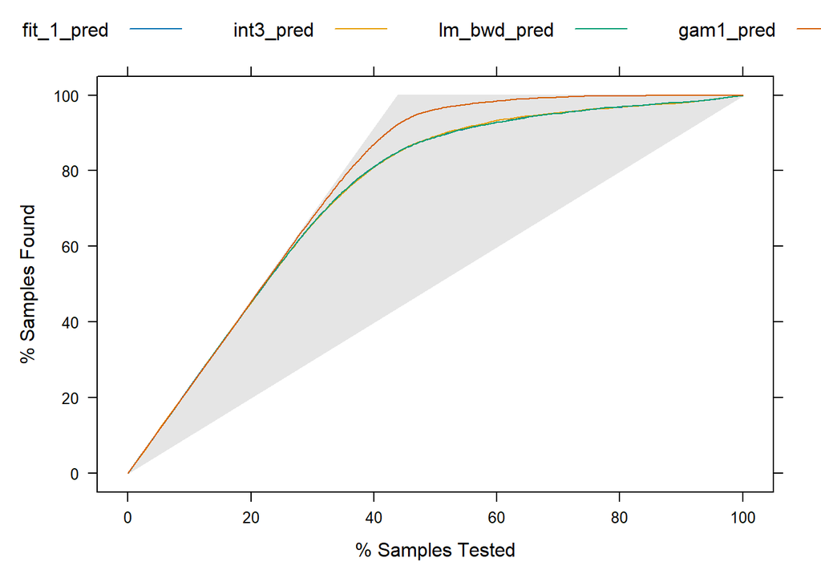

```r
library(lattice)
library(caret)

# Converting our dependent variable as a factor for the lift function to run:
test_use_data$satisfaction <- factor(test_use_data$satisfaction, levels = c(0, 1))
data <- cbind.data.frame(test_use_data$satisfaction, fit_1_pred, int3_pred, lm_bwd_pred, gam1_pred)

lift_chart_u <- caret::lift(test_use_data$satisfaction ~ fit_1_pred + int3_pred + lm_bwd_pred + gam1_pred, class=1, cuts = 200, data = data) # doing this so that it pulls the right lift function from caret90
lift_chart_u <- caret::lift(test_use_data$satisfaction ~ fit_1_pred + int3_pred + lm_bwd_pred + gam1_pred, class=1, cuts = 200, data = data) # doing this so that it pulls the right lift function from caret90

xyplot(lift_chart_u,auto.key=list(columns=4, main='Lift Chart'))
```

## Decision Tree

```r
library(ggplot2)
library(rpart)                      # Popular decision tree algorithm
library(rattle)                 # Fancy tree plot
library(rpart.plot)             # Enhanced tree plots
library(RColorBrewer)               # Color selection for fancy tree plot
library(party)                  # Alternative decision tree algorithm
library(partykit)               # Convert rpart object to BinaryTree
library(caret)
library(reshape2) # Load reshape 2 for melting
library(DMwR) # Load data mining with R for SMOTE
library(splitstackshape) # Used for stratified sampling
```

## Visualize before model:

This is a example of a visualization, we only used online boarding because it was the most influential variable, but other could be plugged in here as well.

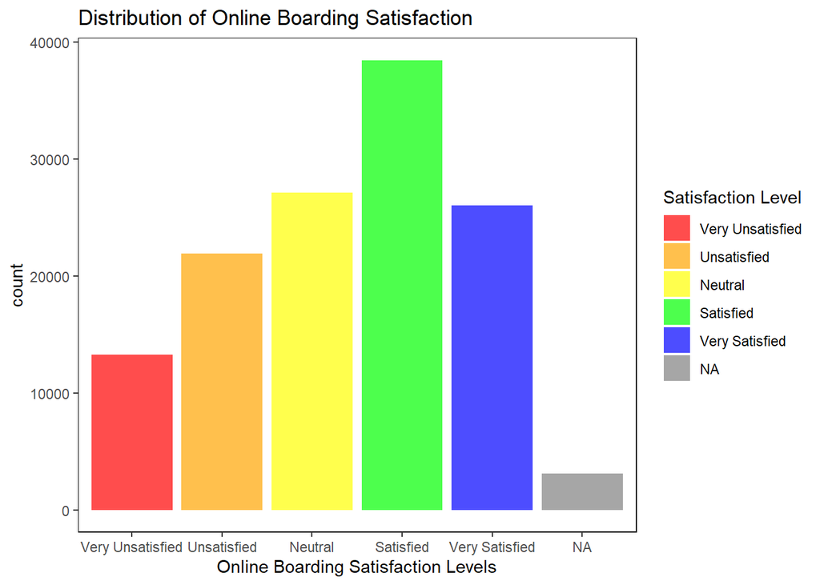

```r
library(ggplot2)

airline_data2 <- airline_data
# Ensure 'Online.boarding' is treated as a factor for categorical visualization
airline_data2$Online.boarding <- factor(airline_data2$Online.boarding,
                                       levels = c(1, 2, 3, 4, 5),
                                       labels = c("Very Unsatisfied", "Unsatisfied",
                                                  "Neutral", "Satisfied",
                                                  "Very Satisfied"))

# Create the density plot for Online.boarding satisfaction levels
g1 <- ggplot(airline_data2, aes(x = Online.boarding, fill = Online.boarding)) +
  geom_bar(alpha = 0.7) +  # Bar plot as density doesn't work well for categorical values
  theme_bw() +
  theme(panel.grid.major = element_blank(),
        panel.grid.minor = element_blank(),
        panel.border = element_rect(color = "black"),
        panel.background = element_blank()) +
  labs(x = "Online Boarding Satisfaction Levels",
       title = "Distribution of Online Boarding Satisfaction",
       fill = "Satisfaction Level") +
  scale_fill_manual(values = c("Very Unsatisfied" = "red",
                               "Unsatisfied" = "orange",
                               "Neutral" = "yellow",
                               "Satisfied" = "green",
                               "Very Satisfied" = "blue"))

# Display the plot
g1
```

[figure not shown]

```r
tree_1 <- rpart(satisfaction ~., # Set tree formula
data = airline_data2[, c(2, 4:25)],
control = rpart.control(cp = 0.001)) # Set dataset
par(xpd = NA) # Set this avoid cut-off text
plot(tree_1)  # Plot tree
text(tree_1, digits = 3) # Add text
```

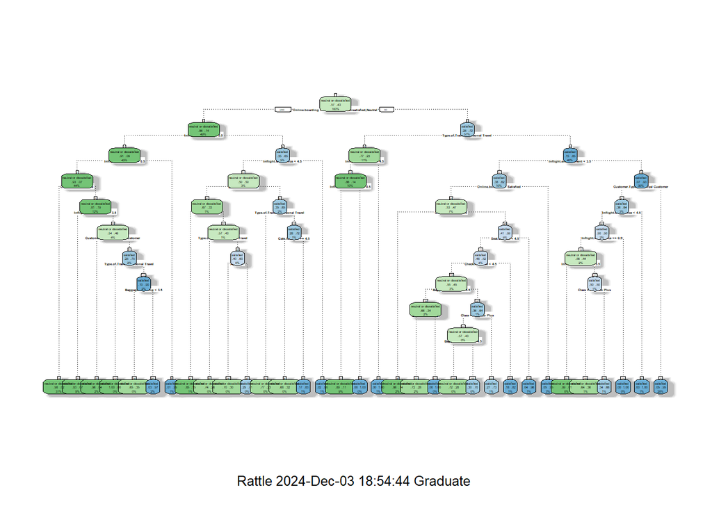

```r
fancyRpartPlot(tree_1, cex = 0.2)
```

```r
tree_1
```

```
## n= 129880
##
## node), split, n, loss, yval, (yprob)
##       * denotes terminal node
##
##    1) root 129880 56428 neutral or dissatisfied (0.565537419 0.434462581)
##      2) Online.boarding=Very Unsatisfied,Unsatisfied,Neutral 64169  9129 neutral or dissatisfied (0.857735043 0.142264957)
##        4) Inflight.wifi.service< 3.5 58316  5352 neutral or dissatisfied (0.908224158 0.091775842)
##          8) Inflight.wifi.service>=0.5 56695  3741 neutral or dissatisfied (0.934015345 0.065984655)
##           16) Class=Eco,Eco Plus 40659   687 neutral or dissatisfied (0.983103372 0.016896628) *
##           17) Class=Business 16036  3054 neutral or dissatisfied (0.809553505 0.190446495)
##             34) Inflight.entertainment< 3.5 11216   836 neutral or dissatisfied (0.925463623 0.074536377) *
##             35) Inflight.entertainment>=3.5 4820  2218 neutral or dissatisfied (0.539834025 0.460165975)
##               70) Customer.Type=disloyal Customer 1958    76 neutral or dissatisfied (0.961184883 0.038815117) *
##               71) Customer.Type=Loyal Customer 2862   720 satisfied (0.251572327 0.748427673)
##                142) Type.of.Travel=Personal Travel 477     0 neutral or dissatisfied (1.000000000 0.000000000) *
##                143) Type.of.Travel=Business travel 2385   243 satisfied (0.101886792 0.898113208)
##                  286) Baggage.handling< 3.5 273    96 neutral or dissatisfied (0.648351648 0.351648352) *
##                  287) Baggage.handling>=3.5 2112    66 satisfied (0.031250000 0.968750000) *
##          9) Inflight.wifi.service< 0.5 1621    10 satisfied (0.006169031 0.993830969) *
##        5) Inflight.wifi.service>=3.5 5853  2076 satisfied (0.354689903 0.645310097)
##         10) Inflight.wifi.service< 4.5 4055  2020 neutral or dissatisfied (0.501849568 0.498150432)
##           20) Gate.location< 3.5 1890   622 neutral or dissatisfied (0.670899471 0.329100529)
##             40) Class=Business 658    97 neutral or dissatisfied (0.852583587 0.147416413) *
##             41) Class=Eco,Eco Plus 1232   525 neutral or dissatisfied (0.573863636 0.426136364)
##               82) Type.of.Travel=Personal Travel 631   167 neutral or dissatisfied (0.735340729 0.264659271) *
##               83) Type.of.Travel=Business travel 601   243 satisfied (0.404326123 0.595673877)
##                166) Age< 40.5 174    53 neutral or dissatisfied (0.695402299 0.304597701) *
##                167) Age>=40.5 427   122 satisfied (0.285714286 0.714285714) *
##           21) Gate.location>=3.5 2165   767 satisfied (0.354272517 0.645727483)
##             42) Type.of.Travel=Personal Travel 345    79 neutral or dissatisfied (0.771014493 0.228985507) *
##             43) Type.of.Travel=Business travel 1820   501 satisfied (0.275274725 0.724725275)
##               86) Gate.location>=4.5 375   120 neutral or dissatisfied (0.680000000 0.320000000) *
##               87) Gate.location< 4.5 1445   246 satisfied (0.170242215 0.829757785) *
##         11) Inflight.wifi.service>=4.5 1798    41 satisfied (0.022803115 0.977196885) *
##      3) Online.boarding=Satisfied,Very Satisfied 65711 18412 satisfied (0.280196619 0.719803381)
##        6) Type.of.Travel=Personal Travel 13821  3159 neutral or dissatisfied (0.771434773 0.228565227)
##         12) Inflight.wifi.service< 4.5 12407  1745 neutral or dissatisfied (0.859353591 0.140646409)
##           24) Inflight.wifi.service>=0.5 12038  1376 neutral or dissatisfied (0.885695298 0.114304702) *
##           25) Inflight.wifi.service< 0.5 369     0 satisfied (0.000000000 1.000000000) *
```

[output cut: 15 more lines]

```
##                    915) Class=Business 1097   291 satisfied (0.265268915 0.734731085) *
##                229) Checkin.service>=4.5 1029   190 satisfied (0.184645287 0.815354713) *
##              115) Seat.comfort>=4.5 1083    43 satisfied (0.039704524 0.960295476) *
##           29) Online.boarding=Very Satisfied 3867   178 satisfied (0.046030515 0.953969485) *
##         15) Inflight.entertainment>=3.5 39206  2933 satisfied (0.074809978 0.925190022)
##           30) Customer.Type=disloyal Customer 3312  1207 satisfied (0.364432367 0.635567633)
##             60) Inflight.wifi.service< 4.5 2417  1207 satisfied (0.499379396 0.500620604)
##              120) Inflight.wifi.service>=0.5 2139   932 neutral or dissatisfied (0.564282375 0.435717625)
##                240) Inflight.wifi.service< 3.5 286     4 neutral or dissatisfied (0.986013986 0.013986014) *
##                241) Inflight.wifi.service>=3.5 1853   925 satisfied (0.499190502 0.500809498)
##                  482) Class=Eco,Eco Plus 974   347 neutral or dissatisfied (0.643737166 0.356262834) *
##                  483) Class=Business 879   298 satisfied (0.339021615 0.660978385) *
##              121) Inflight.wifi.service< 0.5 278     0 satisfied (0.000000000 1.000000000) *
##             61) Inflight.wifi.service>=4.5 895     0 satisfied (0.000000000 1.000000000) *
##           31) Customer.Type=Loyal Customer 35894  1726 satisfied (0.048086031 0.951913969) *
```

#### Evaluate model

```r
# Step 1: Load necessary libraries
library(rpart)
library(rattle)  # For fancyRpartPlot
library(caret)   # For confusionMatrix function

# Step 2: Split the dataset into training and testing sets
set.seed(123)  # Set seed for reproducibility
split_index <- createDataPartition(airline_data2$satisfaction, p = 0.7, list = FALSE)
train_data1 <- airline_data2[split_index, ]
test_data1 <- airline_data2[-split_index, ]

# Step 3: Train the decision tree
tree_1 <- rpart(satisfaction ~ .,
                data = train_data1[, c(2, 4:25)],
                control = rpart.control(cp = 0.001))

# Step 2: Ensure test data matches training data (factor levels)
test_data1$Online.boarding <- as.factor(test_data1$Online.boarding)  # Ensure factor consistency

# Step 3: Make predictions on the test set
predictions <- predict(tree_1, test_data1[, c(2, 4:25)], type = "class")

# Step 4: Generate a confusion matrix
conf_matrix <- confusionMatrix(predictions, as.factor(test_data1$satisfaction))

# Print the confusion matrix and accuracy
print(conf_matrix)
```

```
## Confusion Matrix and Statistics
##
##                          Reference
## Prediction                neutral or dissatisfied satisfied
##   neutral or dissatisfied                   21057      1549
##   satisfied                                   978     15379
##
##                Accuracy : 0.9351
##                  95% CI : (0.9327, 0.9376)
##     No Information Rate : 0.5655
##     P-Value [Acc > NIR] : < 2.2e-16
##
##                   Kappa : 0.8675
##
##  Mcnemar's Test P-Value : < 2.2e-16
##
##             Sensitivity : 0.9556
##             Specificity : 0.9085
##          Pos Pred Value : 0.9315
##          Neg Pred Value : 0.9402
##              Prevalence : 0.5655
##          Detection Rate : 0.5404
##    Detection Prevalence : 0.5802
##       Balanced Accuracy : 0.9321
##
##        'Positive' Class : neutral or dissatisfied
##
```

```r
cat("Accuracy of the model:", round(conf_matrix$overall['Accuracy'] * 100, 2), "%\n")
```

```
## Accuracy of the model: 93.51 %
```

To get important variables from model

```r
#importance from the decision tree of variables
importance <- data.frame(Variable = names(tree_1$variable.importance),
                         Importance = tree_1$variable.importance)
importance <- importance[order(-importance$Importance), ]
print(importance)
```

```
##                                                            Variable  Importance
## Online.boarding                                     Online.boarding 16553.56971
## Inflight.wifi.service                         Inflight.wifi.service 13524.68487
## Seat.comfort                                           Seat.comfort  7886.17767
## Ease.of.Online.booking                       Ease.of.Online.booking  7117.71416
## Inflight.entertainment                       Inflight.entertainment  6658.23591
## Type.of.Travel                                       Type.of.Travel  6567.56264
## Class                                                         Class  6500.93383
## Customer.Type                                         Customer.Type  1314.28624
## Cleanliness                                             Cleanliness  1045.84703
## Age                                                             Age   794.17473
## On.board.service                                   On.board.service   749.82290
## Leg.room.service                                   Leg.room.service   693.47544
## Checkin.service                                     Checkin.service   672.74984
## Departure.Arrival.time.convenient Departure.Arrival.time.convenient   570.64060
## Food.and.drink                                       Food.and.drink   501.93728
## Inflight.service                                   Inflight.service   495.51128
## Gate.location                                         Gate.location   471.65289
## Baggage.handling                                   Baggage.handling   413.00966
## Flight.Distance                                     Flight.Distance   344.08335
## Departure.Delay.in.Minutes               Departure.Delay.in.Minutes    15.71988
## Arrival.Delay.in.Minutes                   Arrival.Delay.in.Minutes    14.81273
```

Important variables to a graph

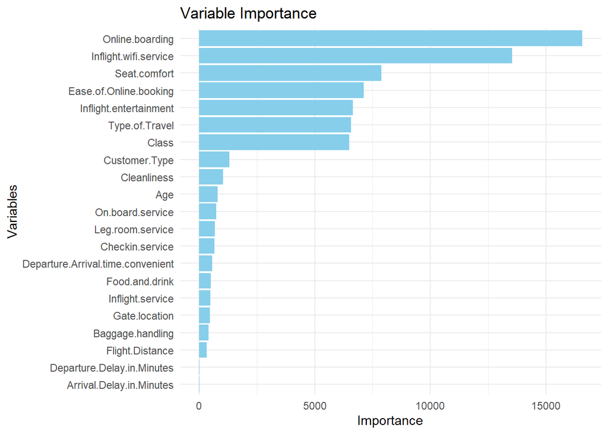

```r
ggplot(importance, aes(x = reorder(Variable, Importance), y = Importance)) +
  geom_bar(stat = "identity", fill = "skyblue") +
  coord_flip() +
  labs(title = "Variable Importance", x = "Variables", y = "Importance") +
  theme_minimal()
```